# Housing Prices in Switzerland

# Load

## Libraries

```r
library(tidyverse)
library(lme4)
library(skimr)
library(scales)
library(caret)
library(doSNOW)
theme_set(theme_light())
```

## Data

Load webscrapped data from Anibis.

```r
d <- read_tsv("../Data/processed/anibis_price_06-04-2019.txt")
```

Skim the data.

```r
skim(d)
```

```
## Skim summary statistics
##  n obs: 53007
##  n variables: 8
##
## ── Variable type:character ────────────────────────────────────────────────────────────────────────────────────────
##  variable missing complete     n min max empty n_unique
##    canton       0    53007 53007   3  25     0       29
##      date       0    53007 53007  10  10     0      881
##  location       1    53006 53007   1  63     0     3129
##    object       2    53005 53007   6  18     0        8
##     title       2    53005 53007   1  60     0    45475
##
## ── Variable type:numeric ──────────────────────────────────────────────────────────────────────────────────────────
##  variable missing complete     n    mean        sd  p0   p25    p50    p75
##     price    7305    45702 53007 7248.23 817005.67 0   980   1480   1900
##     rooms   12965    40042 53007    3.68     32.7  0.5   2.5    3.5    4.5
##   surface   15457    37550 53007  142.69    475.31 1    66     90    120
##         p100     hist
##      1.2e+08 ▇▁▁▁▁▁▁▁
##   6512       ▇▁▁▁▁▁▁▁
##  27000       ▇▁▁▁▁▁▁▁
```

Let’s check the number of listing per category of object.

```r
count(d,object,sort=TRUE)
```

```
## # A tibble: 9 x 2
##   object                 n
##   <chr>              <int>
## 1 Appartement        36858
## 2 Commerce/Industrie  9772
## 3 Place de parc       4430
## 4 Maison              1666
## 5 Autres               134
## 6 Gastronomie          124
## 7 Terrain à bâtir       12
## 8 Agriculture            9
## 9 <NA>                   2
```

We will later exclude objects that are not appartments.

```r
count(d,location,sort=TRUE)
```

```
## # A tibble: 3,130 x 2
##    location              n
##    <chr>             <int>
##  1 zurich             1270
##  2 bâle               1246
##  3 lausanne           1189
##  4 berne              1068
##  5 genève             1021
##  6 st-gall             937
##  7 bienne              704
##  8 la chaux-de-fonds   636
##  9 lucerne             562
## 10 fribourg            531
## # … with 3,120 more rows
```

As expected, listings are more numerous for larger cities.

# Cleaning

Let’s create new columns indicating whether the listing is for shared housing, if a person is asking for housing, if the house has a nice view or if the house is new.

```r
d <- mutate(d,
            coloc = grepl('coloc',title,ignore.case = TRUE),
            ask = grepl('cherche',title,ignore.case = TRUE),
            view = grepl("^vue|\\svue|,vue|\\/vue|blick",title,ignore.case = TRUE),
            new = grepl("neuf|modern|rénové|renoviert",title,ignore.case = TRUE)
            )
```

Variables indicating whether the appartment has a nice view or is modern/new do not significantly improve our models (not shown) but we will keep the code as legacy.

Set the same name for the diverse cities.

```r
d <- mutate(d, location=  case_when(
  location=="zürich" ~ "zurich",
  location=="berne" ~ "bern",
  location=="bâle" ~ "basel",
  location=="carouge ge" ~ "carouge",
  location=="renens vd" ~ "renens",
  TRUE ~ location
))
```

Many cities do not have the right cantons. We will set the canton corresponding to the majority of the location.

```r
canton_clean <- select(d,location,canton) %>% add_count(location,canton) %>% distinct() %>% add_count(location) %>% arrange(location) %>% group_by(location) %>% mutate(canton=canton[which.max(n)]) %>% ungroup() %>% select(location,canton) %>% distinct()
```

Set the right canton for the different cities (based on majority voting).

```r
d <- select(d,-canton) %>% left_join(canton_clean)
```

Only keep appartments, remove colocations and people looking for an appartment

```r
d <- filter(d,object=="Appartement",!coloc,!ask)
```

Let’s check the distribution of prices in the dataset.

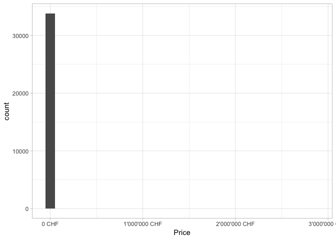

```r
ggplot(d,aes(price)) + geom_histogram() + xlab("Price") + scale_x_continuous(labels = dollar_format(suffix =" CHF", prefix = "",big.mark = "'")) + xlab("Price")
```

Some appartments have unbelivable rents. Let’s remove them.

We will also remove the few rents that are believable but extremly high in order to achieve a nicer distribution.

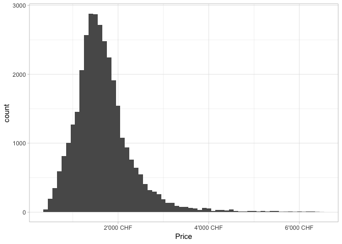

```r
d <- filter(d,price >400, price<6500)
ggplot(d,aes(price)) + geom_histogram(binwidth = 100) + scale_x_continuous(labels = dollar_format(suffix =" CHF", prefix = "",big.mark = "'")) + xlab("Price")
```

## Surface

Let’s now look at surface.

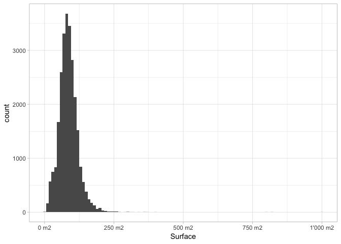

```r
ggplot(d,aes(surface)) + geom_histogram(binwidth = 10) + scale_x_continuous(labels = dollar_format(suffix =" m2", prefix = "",big.mark = "'")) + xlab("Surface")
```

Let’s remove very large surfaces as there are very few data points.

```r
d <- filter(d,surface<250 | is.na(surface))
```

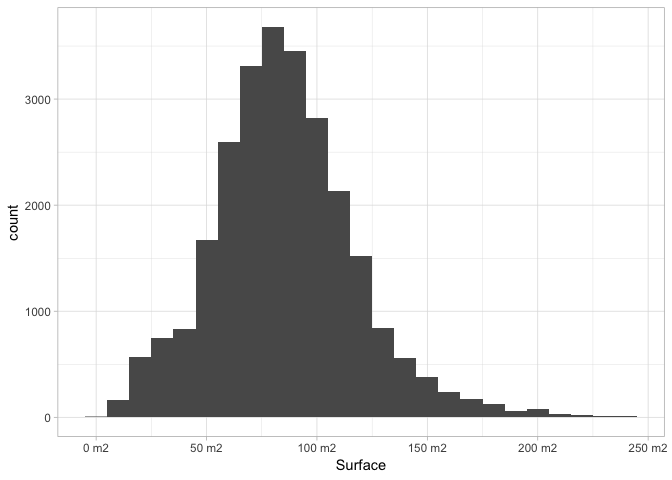

```r
ggplot(d,aes(surface)) + geom_histogram(binwidth = 10) + scale_x_continuous(labels = dollar_format(suffix =" m2", prefix = "",big.mark = "'")) + xlab("Surface")
```

## Rooms

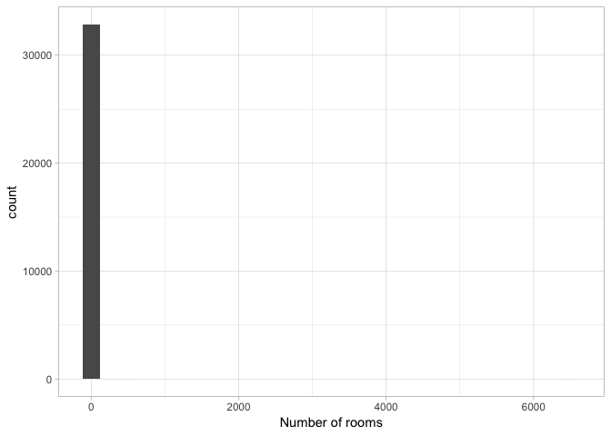

```r
ggplot(d,aes(rooms)) + geom_histogram() + xlab("Number of rooms")
```

Let’s remove appartments with more than 8 rooms

```r
d <- filter(d,rooms<8 | is.na(rooms))
```

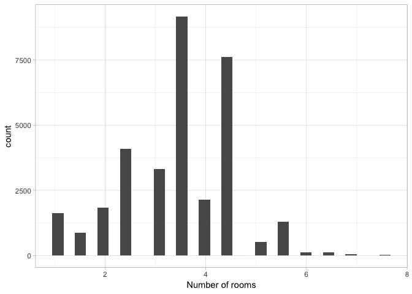

```r
ggplot(d,aes(rooms)) + geom_histogram(boundary = 0.5) + xlab("Number of rooms")
```

## Missing data

Let’s also remove listings where both surface and number of rooms are missing.

```r
d <- filter(d,
            !(is.na(surface) & is.na(rooms))
            )
```

## Remove duplicates

```r
d <- distinct(d)
```

# Visualisation

## Surface vs Price per canton

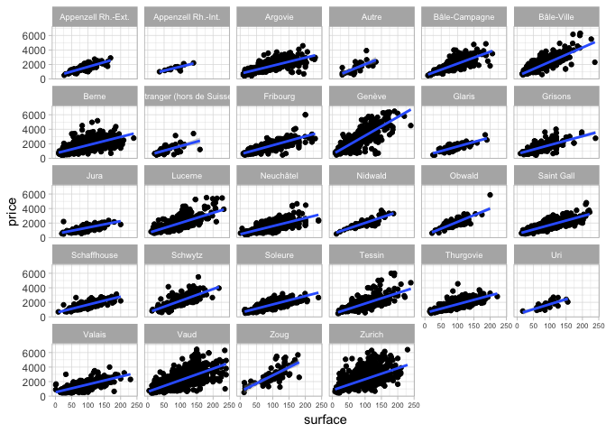

```r
ggplot(d,aes(surface,price)) + geom_point() + geom_smooth(method="lm") + facet_wrap(~canton) + theme(strip.text.x = element_text(size = 7),axis.text.x = element_text(size = 6))
```

We can clearly see that the relationship between surface and price is different in different cantons.

## Rooms vs Price per canton

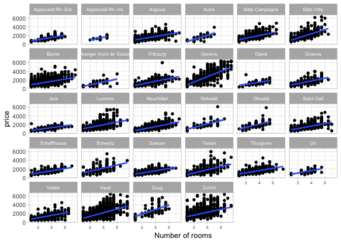

```r
ggplot(d,aes(rooms,price)) + geom_point() + geom_smooth(method="lm") + facet_wrap(~canton) + theme(strip.text.x = element_text(size = 7),axis.text.x = element_text(size = 6)) + xlab("Number of rooms")
```

## Rooms vs surface per canton

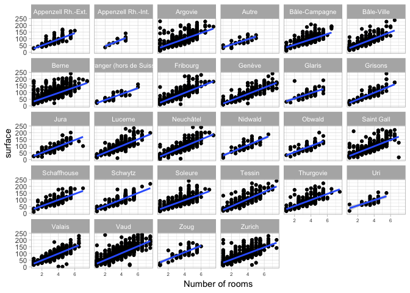

```r
ggplot(d,aes(rooms,surface)) + geom_point() + geom_smooth(method="lm") + facet_wrap(~canton) + theme(strip.text.x = element_text(size = 8),axis.text.x = element_text(size = 6)) + xlab("Number of rooms")
```

The relationship between number of rooms and surface is quite linear (as expected).

# Modeling

## Functions

Functions to assess models:

### Root mean square error

```r
rmse <- function(model){
  residuals(model)^2 %>% mean() %>% sqrt()
}
```

### Mean absolute error

```r
mae <- function(model){
  residuals(model) %>% abs() %>% mean()
}
```

### Fixed intercept

Get the value of the fixed intercept

```r
fixed_intercept <- function(model){
  coef(summary(model))[1]
}
```

## Split Data

We will train our model using 80% of the data and test prediction on the remaining 20%.

```r
set.seed(123)
train_index <- createDataPartition(d$price,p=0.8,list = FALSE)
train <- d[train_index,]
test <- d[-train_index,]
```

## Imputation

We will impute missing data using linear regression.

Let’s first create the linear regression models using the training data

```r
model_imputation_surface <- lm(surface ~ rooms,data=train)
model_imputation_rooms <- lm(rooms ~ surface,data=train)
```

Let’s replace missing values for surface in the training data by the predicted values

```r
train_surface_prediction <- predict(model_imputation_surface,select(train,rooms))
train <- mutate(train, surface=ifelse(is.na(surface),train_surface_prediction,surface))
```

Let’s replace missing values for surface in the test data by the predicted values

```r
test_surface_prediction <- predict(model_imputation_surface,select(test,rooms))
test <- mutate(test, surface=ifelse(is.na(surface),test_surface_prediction,surface))
```

Let’s replace missing values for the number of rooms in the training data by the predicted values

```r
train_rooms_prediction <- predict(model_imputation_rooms,select(train,surface))
train <- mutate(train, rooms=ifelse(is.na(rooms),train_rooms_prediction,rooms))
```

Let’s replace missing values for the number of rooms in the test data by the predicted values

```r
test_rooms_prediction <- predict(model_imputation_rooms,select(test,surface))
test <- mutate(test, rooms=ifelse(is.na(rooms),test_rooms_prediction,rooms))
```

## Baseline

We will set the mean for surface to 100 m2 and 4 rooms. We will also scale the variables for easier computations.

```r
sd_surface  <- sd(train$surface)
sd_rooms <- sd(train$rooms)
train <- mutate(train,surface=(surface-100)/sd_surface,rooms=(rooms-4)/sd_rooms)
test <- mutate(test,surface=(surface-100)/sd_surface,rooms=(rooms-4)/sd_rooms)
```

## Mixed Models

Different models (linear and mixed) will be trained.

```r
model0 <- lm(price ~ surface + rooms,data = train)
model1 <- lmer(price ~ surface + rooms + (1|canton),data = train)
model2 <- lmer(price ~ surface + rooms + (1|canton) + (1|location),data = train)
model3 <- lmer(price ~ surface + rooms + (1|location) ,data = train)
model4 <- lmer(price ~ surface + rooms + (rooms|location) ,data = train)
model5 <- lmer(price ~ surface + rooms + (surface|location) ,data = train)
model6 <- lmer(price ~ surface + rooms + (surface|location) + (0+rooms|location),data = train)
model7 <- lmer(price ~ surface + rooms + (surface + rooms|location),data = train)
model8 <- lmer(price ~ surface + rooms + (surface|location) + (1|canton),data = train)
```

Model 6 & 7 fail to converge and therefore will not be our final models.

## Mixed model results

```r
models <- list(model0,model1,model2,model3,model4,model5,model6,model7,model8)
model_calls <- c(model0$call,model1@call,model2@call,model3@call,model4@call,model5@call,model6@call,model7@call,model8@call) %>% as.character()

models_df <- tibble(name=paste0("model",0:8),
                    calls=model_calls,
                    rmse=map_dbl(models,rmse) %>% round(),
                    mae=map_dbl(models,mae) %>% round(),
                    fixed_intercepts=map_dbl(models,fixed_intercept) %>% round())
```

Test prediction for the city of Lausanne.

```r
lausanne <- tibble(surface=0,rooms=0,location="lausanne",canton="Vaud",view=FALSE,new=FALSE)
```

```r
models_df <- mutate(models_df,`predicted price Lausanne`=map_dbl(models,predict,lausanne) %>% round()) %>% arrange(rmse)
```

```r
models_df
```

```
## # A tibble: 9 x 6
##   name   calls               rmse   mae fixed_intercepts `predicted price …
##   <chr>  <chr>              <dbl> <dbl>            <dbl>              <dbl>
## 1 model7 lmer(formula = pr…   302   202             1790               2610
## 2 model6 lmer(formula = pr…   305   205             1789               2622
## 3 model5 lmer(formula = pr…   307   206             1789               2633
## 4 model8 lmer(formula = pr…   307   206             1795               2632
## 5 model4 lmer(formula = pr…   316   212             1792               2586
## 6 model3 lmer(formula = pr…   338   227             1807               2385
## 7 model2 lmer(formula = pr…   340   229             1837               2383
## 8 model1 lmer(formula = pr…   416   283             1900               2119
## 9 model0 lm(formula = pric…   492   334             1876               1876
```

## Machine Learning

Now that we’ve used linear regression and mixed models, we will compare them to different ML algorithms.

```r
y_train <- train$price
y_test <- test$price
```

Select variables to use

```r
x_train <- select(train,price,surface,rooms,location,canton)
x_test <- select(test,price,surface,rooms,location,canton)
```

Set categorical variables to factors

```r
dummies_model <- dummyVars(price~ ., data=x_train)
x_train <- predict(dummies_model, newdata = x_train) %>% as.data.frame()
x_test <- predict(dummies_model, newdata = x_test) %>% as.data.frame()
```

Remove near zero variables.

```r
nzv <- nearZeroVar(x_train)
x_train <- x_train[-nzv]
x_test <-  x_test[-nzv]
```

Create 10 folds for 10-fold cross-validation

```r
index_train <- createFolds(y_train,k=10,list=TRUE,returnTrain = TRUE)
```

Use three cores for the ML modeling

```r
cl <- makeCluster(3,type= "SOCK")
registerDoSNOW(cl)
```

Sets cross-validation parameters

```r
trainControl <- trainControl(method="cv", index=index_train,number = 10)
```

## ML Modeling

We will test linear regression, KNN, random forest, xgboost and ridge/lasso regression.

```r
model_lm = train(y=y_train, x=x_train,
                  method='lm',
                  trControl = trainControl)

model_knn = train(y=y_train, x=x_train,
                  method='knn',
                  trControl = trainControl)

model_ranger = train(y=y_train, x=x_train,
                     method='ranger',
                     trControl = trainControl)

model_xgboost = train(y=y_train, x=x_train,
                      method='xgbTree',
                      trControl = trainControl)

model_glmnet = train(y=y_train, x=x_train,
                      method='glmnet',
                      trControl = trainControl,
                      tuneGrid = expand.grid(alpha = 0:1,lambda = seq(0.001,0.1,by = 0.001)))
```

## Compare ML models

Let’s check how the different models compare using results from the cross-validation.

```r
models_compare <- resamples(list(Lm=model_lm,
                                 Ranger=model_ranger,
                                 knn=model_knn,
                                 Xgboost=model_xgboost,
                                 glmnet=model_glmnet))
summary(models_compare)
```

```
##
## Call:
## summary.resamples(object = models_compare)
##
## Models: Lm, Ranger, knn, Xgboost, glmnet
## Number of resamples: 10
##
## MAE
##             Min.  1st Qu.   Median     Mean  3rd Qu.     Max. NA's
## Lm      301.1902 306.1305 309.0814 310.7221 314.9794 323.7271    0
## Ranger  278.3518 290.6955 293.4579 292.0922 294.3544 301.2753    0
## knn     280.3445 296.5059 297.8034 296.5820 299.1208 305.5464    0
## Xgboost 279.8079 290.3728 292.0787 291.5065 293.5514 300.5262    0
## glmnet  300.9860 305.8211 308.8112 310.4234 314.5875 323.4203    0
##
## RMSE
##             Min.  1st Qu.   Median     Mean  3rd Qu.     Max. NA's
## Lm      441.3593 450.1320 461.8320 461.5338 466.9640 487.8919    0
## Ranger  415.5581 432.5006 446.4543 442.0432 448.3372 465.7900    0
## knn     421.6195 440.8184 452.0785 449.4998 456.8411 473.8000    0
## Xgboost 418.9834 432.0296 442.4203 441.0769 446.8819 465.1206    0
## glmnet  441.2512 450.0560 461.9204 461.5430 466.9581 487.9303    0
##
## Rsquared
##              Min.   1st Qu.    Median      Mean   3rd Qu.      Max. NA's
## Lm      0.4694050 0.4777196 0.4942052 0.4906608 0.5021820 0.5105207    0
## Ranger  0.5072516 0.5225624 0.5264406 0.5329002 0.5407893 0.5677893    0
## knn     0.4879217 0.5054467 0.5151670 0.5179723 0.5311261 0.5549223    0
## Xgboost 0.5065744 0.5252398 0.5361669 0.5351276 0.5450178 0.5608430    0
## glmnet  0.4693443 0.4777482 0.4941774 0.4906385 0.5020738 0.5106891    0
```

## ML Plot

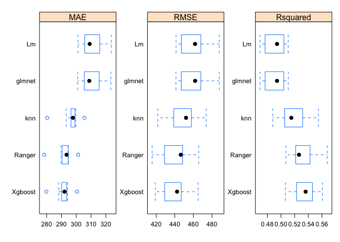

```r
scales <- list(x=list(relation="free"), y=list(relation="free"))
bwplot(models_compare, scales=scales)
```

Machine learning models are all much worse than mixed model for this dataset. We will use a mixed model for housing prediction.

```r
stopCluster(cl)
```

# Test Set

```r
test$model0 <- predict(model0,test) %>% as.numeric()
test$model1 <- predict(model1,test,allow.new.level=TRUE) %>% as.numeric()
test$model2 <- predict(model2,test,allow.new.level=TRUE) %>% as.numeric()
test$model3 <- predict(model3,test,allow.new.level=TRUE) %>% as.numeric()
test$model4 <- predict(model4,test,allow.new.level=TRUE) %>% as.numeric()
test$model5 <- predict(model5,test,allow.new.level=TRUE) %>% as.numeric()
test$model6 <- predict(model6,test,allow.new.level=TRUE) %>% as.numeric()
test$model7 <- predict(model7,test,allow.new.level=TRUE) %>% as.numeric()
test$model8 <- predict(model8,test,allow.new.level=TRUE) %>% as.numeric()
```

```r
test <- gather(test,model,prediction,model0:model8)
```

```r
test <- mutate(test, error=price-prediction)
```

```r
test_results <- test %>% group_by(model) %>% summarise(rmse=error^2 %>% mean() %>% sqrt() %>% round(),mae=error %>% abs() %>% mean() %>% round()) %>%
  arrange(rmse)
```

```r
test_results
```

```
## # A tibble: 9 x 3
##   model   rmse   mae
##   <chr>  <dbl> <dbl>
## 1 model8   340   225
## 2 model7   341   226
## 3 model5   342   227
## 4 model6   342   227
## 5 model4   348   232
## 6 model2   360   240
## 7 model3   363   242
## 8 model1   416   278
## 9 model0   491   330
```

We will keep model 8 due to great performance.

lmer(formula = price ~ surface + rooms + (surface | location) + (1 | canton), data = train)

## Save model

```r
saveRDS(model8, "../Data/processed/mixed_model8.rds")
saveRDS(sd_surface,"../Data/processed/mixed_model_sd_surface.rds")
saveRDS(sd_rooms,"../Data/processed/mixed_model_sd_rooms.rds")
```

## Save locations

```r
select(d,location,canton) %>% unique() %>% saveRDS("../Data/processed/location_canton_anibis.rds")
```